# Peloton Progress Report

05 January, 2021

[interactive chart not shown]

[via GIPHY](https://giphy.com/gifs/onepeloton-peloton-cody-rigsby-its-not-that-deep-boo-8kJxY6NgLtfAiMRSAB)

### Your profile

Username: **acadiaDad**

[figure not shown]

[figure not shown]

### The basics

🤸

You’ve spent **56 hours** working out on your Peloton! You have completed 176 classes on the app. Here are some of your basic performance stats, with 0-20 min classes excluded to filter out cool down classes and short rides. On average, you finish in the **top 39%** of riders in your classes. Your average output is **123 W**. Your mean total output in +20 min rides is **239 KJ** Nice work!

### Classes taken

🚲 😄

Here are the 176 classes you have taken so far. You can sort the table or filter to see individual class types, or to look at your best performances. Scroll to the right to view your total output and rank compared to other riders in the class:

| Date | Type | Title | Instructor | Image | mins | PR | Average Output | Total Output | Your Rank | Total Riders | Top __% | Difficulty |
| --- | --- | --- | --- | --- | --- | --- | --- | --- | --- | --- | --- | --- |
| 2021-01-05 | stretching | 5 min Post-Ride Stretch | Kendall Toole |  | 5 mins |  | 0 | 0 |  | 0 |  | 3.6512 |
| 2021-01-05 | Cycling 🚲 | 30 min Peloton Top 50 of 2020 (#10 - 01) | Kendall Toole |  | 30 mins |  | 140 | 252 | 73773 | 218152 | 0.33817246690381 | 7.8787 |
| 2021-01-04 | stretching | 5 min Post-Ride Stretch | Cody Rigsby |  | 5 mins |  | 0 | 0 |  | 0 |  | 3.4019 |
| 2021-01-04 | Cycling 🚲 | 30 min Peloton Top 50 of 2020 (#20 - 11) | Cody Rigsby |  | 30 mins |  | 126 | 227 | 66619 | 218191 | 0.305324234271808 | 7.5801 |
| 2021-01-03 | meditation | 10 min Fitness Goals Meditation | Ross Rayburn |  | 10 mins |  | 0 | 0 |  | 0 |  | 0 |
| 2021-01-02 | Cycling 🚲 | 30 min Peloton Top 50 of 2020 (#30 - 21) | Alex Toussaint |  | 30 mins |  | 130 | 234 | 58678 | 152383 | 0.385069200632617 | 7.9745 |
| 2021-01-01 | meditation | 5 min Breathing Meditation | Chelsea Jackson Roberts |  | 5 mins |  | 0 | 0 |  | 0 |  | 2.7882 |
| 2020-12-31 | Strength 💪 | 10 min Elvis Remix Core Strength | Emma Lovewell |  | 10 mins |  | 0 | 0 |  | 0 |  | 0 |
| 2020-12-30 | Cycling 🚲 | 30 min Peloton Top 50 of 2020 (#40 - 31) | Leanne Hainsby |  | 30 mins |  | 128 | 231 | 36879 | 96925 | 0.380490069641475 | 0 |
| 2020-12-29 | meditation | 5 min Courage Meditation | Kristin McGee |  | 5 mins |  | 0 | 0 |  | 0 |  | 0 |

[output cut: 166 more lines]

### Favorite Instructors

Your favorite instructor is **Kendall Toole** . You’ve taken **37** of their classes!

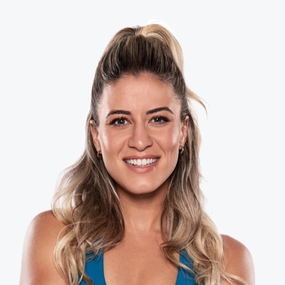

|  | Instructor | Classes | Total Minutes | Average Difficulty |
| --- | --- | --- | --- | --- |
|  | Kendall Toole | 37 | 892.616666666667 | 7.1559972972973 |
|  | Cody Rigsby | 22 | 426.783333333333 | 6.40439090909091 |
|  | Robin Arzón | 21 | 476.283333333333 | 7.12337619047619 |
|  | Ally Love | 16 | 344.15 | 7.0972375 |
|  | Chelsea Jackson Roberts | 15 | 90.5833333333333 | 3.13644666666667 |
|  | Leanne Hainsby | 12 | 193.183333333333 | 5.44945 |
|  | Jess Sims | 8 | 92.9166666666667 | 5.5529 |
|  | Hannah Corbin | 5 | 158.583333333333 | 7.3732 |
|  | Sam Yo | 5 | 65.5833333333333 | 5.17386 |
|  | Anna Greenberg | 4 | 39.0166666666667 | 2.953125 |

[output cut: 12 more lines]

### Performance

💪 😄

Here is how your average output is trending over time:

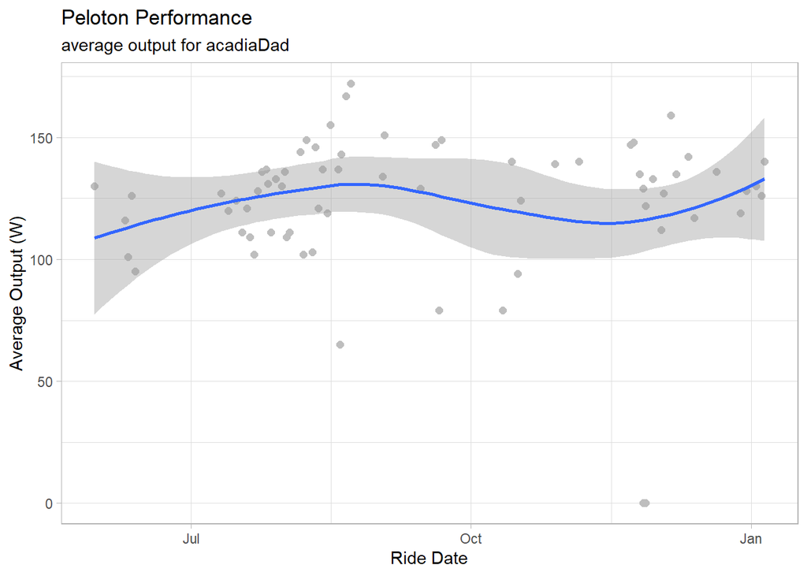

#### Average output by day of the week

Grey dots represent individual workouts, with the darker dots representing the average for that day of the week

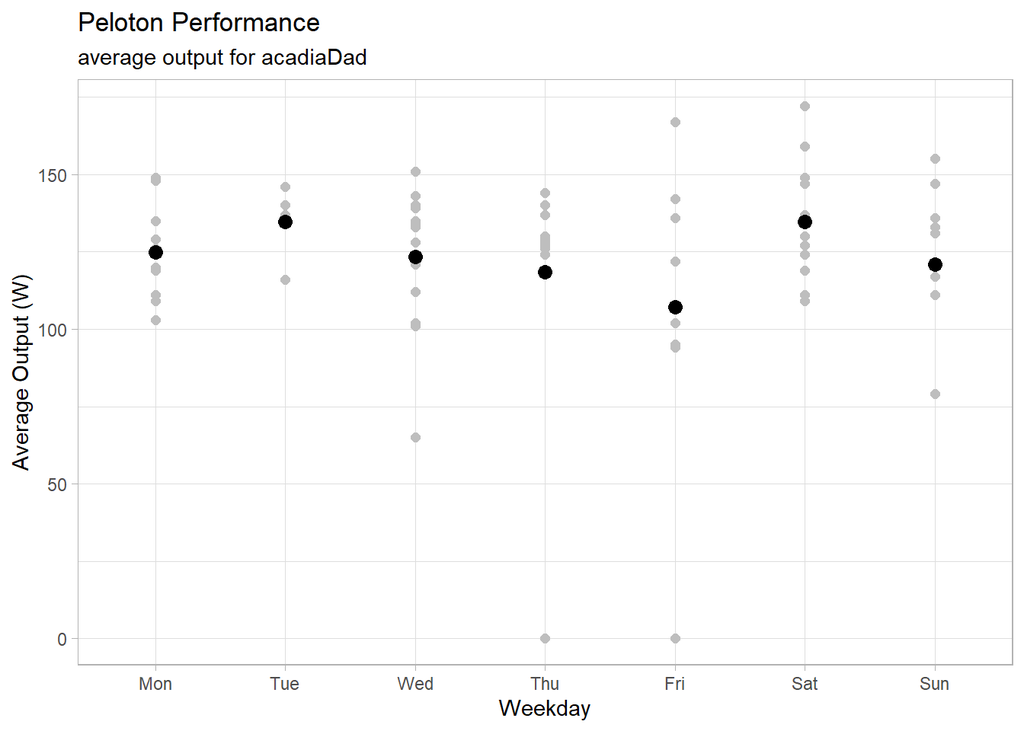

#### Who pushes you the hardest?

In classes over 20 minutes long, **Olivia Amato** pushes you the hardest! Your output is **137 W** in their classes!

[figure not shown]

| Instructor |  | Classes over 20 mins | Average Output |
| --- | --- | --- | --- |
|  | Olivia Amato | 1 | 137 |
|  | Ally Love | 8 | 136 |
|  | Jenn Sherman | 1 | 136 |
|  | Christine D'Ercole | 1 | 135 |
|  | Jess King | 1 | 134 |
|  | Alex Toussaint | 1 | 130 |
|  | Cody Rigsby | 7 | 130 |
|  | Emma Lovewell | 2 | 128 |
|  | Robin Arzón | 12 | 128 |
|  | Kendall Toole | 20 | 126 |

[output cut: 7 more lines]

### Schedule

⏳

Here is how much time you have spent on the bike on days you worked out:

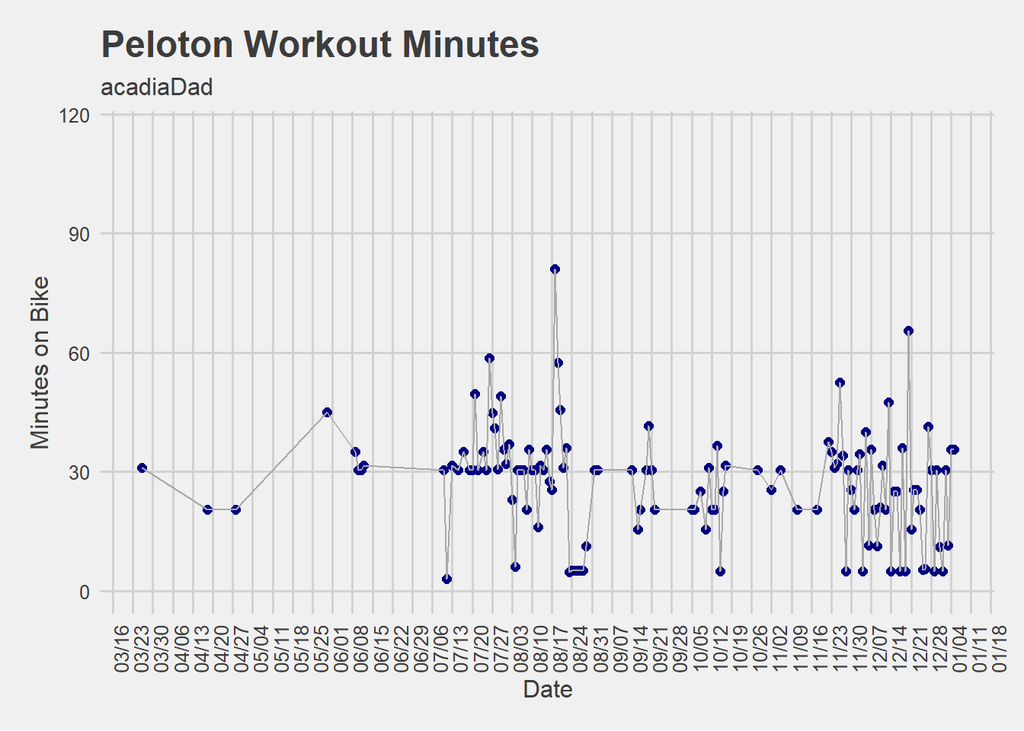

[interactive chart not shown]

[via GIPHY](https://giphy.com/gifs/onepeloton-SwS7xJCrjtwYyUgD1P)

### That’s all for now!

Made by Christian Dittmeier using RMarkdown and the pelotonR package provided by bweiher on Github